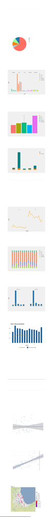

Prosjektoppgave 1005

Oppgave 2 - ukentlig salgsrapport

I en ukentlig salgsrapport får vi en detaljert analyse av salgsdataene gjennom en

kortere periode. Vi har valgt å fokusere på butikk 64, som har solgt mest i 1990!(uke 6,

7, 8 og 9). I tillegg til å se nærmere på et butikknivå, har vi også valgt å analysere hvert

enkelt varemerke i den ukentlige salgsrapporten. Dette gir oss innsikt i

markedsandeler,!og hvilke varemerker som bidrar mest til salg, profitt og prising. !

Varetypen vi fikk utdelt var "crackers".!

Salgsfordelig!

Figur 1 er et kakediagram som visualiserer markedsandelen til de fem største merkene

innen "crackers" kategorien i den valgte perioden. Kakediagrammet gir en enkel og

visuell representasjon av forholdet mellom de ulike merkene og deres andel av det

totale markedet. Basert på figur 1 ser vi tydelig at NAB har en betydelig større

markedsandel enn de fire andre konkurrentene i Chicago området.!

Salgsutvikling!

Figur 2 er!et sø ylediagram som viser salgsinntektene for de fem valgte merkene

innenfor “crackers”-markedet i Chicago over de fire valgte ukene. Denne typen

sø ylediagram viser ukentlige!forskjeller tydelig, og sammenligner merkene side ved

side. Diagrammet viser at!merkene opplevde gjennomgående!gode!salg i uke 6, hvor

Nab, Keebler og Sunshine hadde sine!hø yeste salgstall gjennom perioden. For Old og

Salerno var uke 6 deres nest beste uke.!!

Proffitmargin!

For å evaluere lønnsomheten til hvert enkelt merke, ser vi på profittmarginene.

Profittmarginen viser hvor stor andel av hver dollar i salg som blir til profitt, så!en

hø yere profittmargin gir bedre fortjeneste per vare.!

Figur 3 illustrerer at Sunshine er det merket som mest effektivt konverterer salg til

profitt, med over 40 prosent av!salgspris som ren profitt.!Salerno har den laveste

profittmarginen per salg. Det er også verdt å merke seg at Salerno er et merke med

lavt salgsvolum i det valgte utsalget. Salerno er dermed trolig ikke et merke det er

verdt å satse på videre, da det verken genererer!mye!profitt eller har høye salgstall. !!

Profitt og gjennomsnittlig pris!

Figur 4 er et "stacked bar plot" som sammenligner den totale profitten generert i

perioden med gjennomsnittlig pris pr vare. Fordelen med et slikt plot er at det gjør

forskjeller lett å observere, og det gjør sammenligninger med flere variabler lett

fordøyelig. Vi kan her se NAB har ekstremt høye tall for profitt i forhold til prisen, i

motsetning til Keebler, som har de dyreste crackersene, men ikke store profitter. !

I figur 4 er summen av profitt delt på 10, slik at den gjennomsnittlige prisen skal være

synlig og tolkbar.

Oppgave 3 - Månedlig salgsrapport

En månedlig salgsrapport gir en omfattende oversikt over salgsdataene over en lengre

periode. Vi fokuserer på hele året 1990 og analyserer salget til butikk 80 og butikk 75.

Store 75 – sentralt i Chicago er den butikken med lavest medianinntekt pr kunde, mens

Store 80 – i Arlington Heights, er i toppen av inntekskalaen !

Ved å se på salgstallene og trender i løpet av året 1990 for disse butikkene, får vi

innsikt i deres utvikling i denne perioden. Vi ser også nærmere på hvert enkelt

varemerke for å finne ut hvilke merker som bidrar mest til salgsøkningen i hver av

butikkene.!Vi ser også på kupongbruk og nærmere på demografien av kundene som

handler der.!

Tot alt salg per butikk - månedlig!

Figur 5 viser det totale salget for hver butikk i løpet av året. Ved å se på det totale

salget i hver butikk månedlig, får vi innsikt i hvordan hver av butikkene har presterert

over tid. Vi ser her at butikk 80 har store forskjeller gjennom året, med store hopp

enkelte måneder. !Samtidig holder store 75 seg på et lavere nivå med færre merkbare

endringer løpet av året. !!

Figur 6 viser det totale salget for begge butikker i prosentandel (1 sø yle = 100 %) og

den relative andelen som hver av merkene bidrar til salget på månedsbasis. Denne

typen figur er nyttig i en salgsrapport da den på en effektiv og enkel måte viser hvor

stor andel av det totale salget hvert merke representerer til enhver tid. NAB har

generelt sett den stø rste markedsandelen blant de fem merkene i våre utsalg med

unntak av måned!3, hvor!Sunshine hadde en sterk periode.!

Promoterte uker – hva gjør promoteringer med salg?!

Gjennom året har det vært flere uker med salg og promoteringer. Vi ser her nærmere

på om salg i disse ukene bidrar til økt salg eller profitt.!

Tot alt salg og kupongbruk etter merke

Figur 7 viser totale salg per merke, og antall promosjonskuponger brukt.! Selv om

skalaene er forskjellige, ser det ut til at mengden kuponger brukt i forhold til salg er

tilnærmet like, med noe mer kupongbruk i butikk 80. !

Tot ale salg og kupongbruk for alle merker !!

Figur 8 viser det totale salget av "crackers" månedlig på tvers av merker gjennom året,

og linjen indikerer hvor mange promosjonskuponger som blir brukt i hver enkelt

måned. Dette viser oss koorelasjonen mellom salg og kuponger som helhet. Fra dataen

virker det som disse koorelerer noe mindre enn forventet, og tyder ikke på at perioder

med økt salg er et produkt av flere promosjonskuponger brukt.!

Demografi - tabell

Tabell 1 sammenligner Store 75 – Chicago, med Store 80 – i Arlington Heights. Tabeller

er fine å bruke i salgsrapporter, da de gir en enkel sammenligning, organisering, og det

er lett for enhver å tolke dataen.!

i!Arlington. Medianinntekten i området rundt butikken i Arlington er betydelig større

enn dette i området rundt butikken i Chicago.!Altså handler i dette tilfellet de fattigere

på en dyrere butikk – hvertfall når det kommer til crackers. Selv om antallet kunder på

de to butikkene er ganske likt, kjøpes det mye mer crackers på butikken med hø yere

median inntekt. Det er nærliggende å anta at dette kommer av at crackers er langt fra

en nødvendighet - og dermed er det større etterspørsel fra de rikere inntektsgruppene.

Vi ser nærmere på dette i oppgave 4.!

Butikk Pro fittmar gin

Median

inntek t Trafikk Salg

Gjennomsnittlig

pris

75 28.50216 19284.99 18467119 50857.89 1.920129

80 27.20144 54694.02 22067752 150419.70 1.900824

Oppgave 4 - nye utsalg

For å kunne benytte den tilgjengelige dataen til å gi et grunnlag for hvor det er gunstig

å sette opp et nytt utsalg, må vi se om det er noen spesifikke verdier som koorelerer

med salgstallene. Vi ser derfor nærmere på koorelasjonen mellom inntekten til

kundene, og hvor mye crackers de handler. Vi ser også på sammenhengen mellom

antall kunder som besøker butikkene og det!totale salget.!

Sammenheng mellom inntekt og totale salg av crackers!

Figur 9 er et!scatterplottet som inkluderer!alle butikkene i datasettet. Y aksen viser

deres totale salg, og X aksen viser medianinntekten til kundene på den gitte butikken.

Vi kjører!en regresjonsanalyse for å se nærmere på disse tallene, og om de!påvirker

hverandre på noen måte. Ut fra denne viser at det!ikke finnes noen reell sammenheng

mellom medianinntekt og cracker salg i Chicago, til tross for funnene våre fra oppgave

3.!

Sammenheng mellom antall kunder og salg!

Figur 10!sammenligner antall besøkende kunder på hver butikk med deres totale salg.

Som!antatt har disse en klar relasjon, hvor salget øker når antall kundebesøk øker.

Grunnet dette vil vi heller fokusere på besøkstallet til de aktuelle områdene,

ikke!medianinntekt. Vi vil derfor heller plassere det nye utsalget i et området med hø y

trafikk.!!!

Aktuelle områder i Chicago!!!

Figur 11!er et kart over Chicago, med data for kundebesøk og antall salg. Besøkstall

vises som farge (rød = stor trafikk) og salg vises som størrelsen på punktene. Som

nevnt ovenfor ser vi etter store besøkstall når vi plasserer det nye utsalget. Som en kan

se i figur 11,!har utsalgene med store besøkstall,!ofte de beste!salgstallene.!Vi vil derfor

anbefale å plassere det nye utsalget i et område med store besøkstall, og mye

omsetning. !

66%

10.2%

9.63%

9.09%

5.08%

NAB

SUNSHINE

KEEBLER

SALERNO

OLD

Figur 1: Markedsandel etter merke

6 7 8 9

0

500

1000

1500

6 7 8 9 6 7 8 9 6 7 8 9 6 7 8 9

KEEBLER

NAB

OLD

SALERNO

SUNSHINE

Figur 2: Salgsanalyse ukentlig etter merke

Uke

Salg

KEEBLER NAB OLD SALERNO SUNSHINE

KEEBLER NAB OLD SALERNO SUNSHINE

0

10

20

30

40

KEEBLER

NAB

OLD

SALERNO

SUNSHINE

Figur 3: Profitmargin etter merke

Profittmargin %

KEEBLER NAB OLD SALERNO SUNSHINE

0

25

50

75

100

Sum Profit

Avg Price

Figur 4: Profitt og gjennomsnittlig pris analyse etter merke

5 10

4000

8000

12000

16000

5 10

Figur 5: Salgsanalyse etter butikk

Måned

Salg

75 80

5 10

0

25

50

75

100

KEEBLER

NAB

OLD

SALERNO

SUNSHINE

Figur 6: Prosentvis bidrag av salg etter merke

Måned

Bidrag i prosent

KEEBLER

NAB

OLD

SALERNO

SUNSHINE

0

10000

20000

30000

KEEBLER

NAB

OLD

SALERNO

SUNSHINE

0

25000

50000

75000

100000

Figur 7: Salg og kupongbruk

Salg

STORE: 75 STORE: 80

20,000 40,000 60,000

60000

90000

120000

150000

Figur 9: Regresjonsanalyse av medianinntekt og totale salg

Medianinntekt

Totale salg

10,000,000 15,000,000 20,000,000 25,000,000

60000

90000

120000

150000

Figur 10 - regresjonsanalyse av trafikk og totale salg

Besøkstall

Salg